# Project 1: Explore and Prepare Data

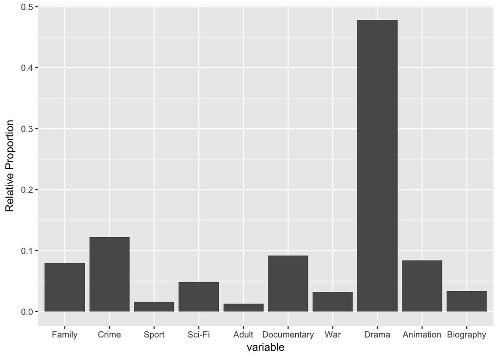

```r
# Finally plot relative proportions
# https://sebastiansauer.github.io/percentage_plot_ggplot2_V2/
ggplot(df3.long, aes(x=variable)) +
  geom_bar(aes(y = (..count..)/sum(..count..))) +
  ylab('Relative Proportion')
```

Examine how the distribution of `Runtime` changes across genres for the top 10 most common genres.

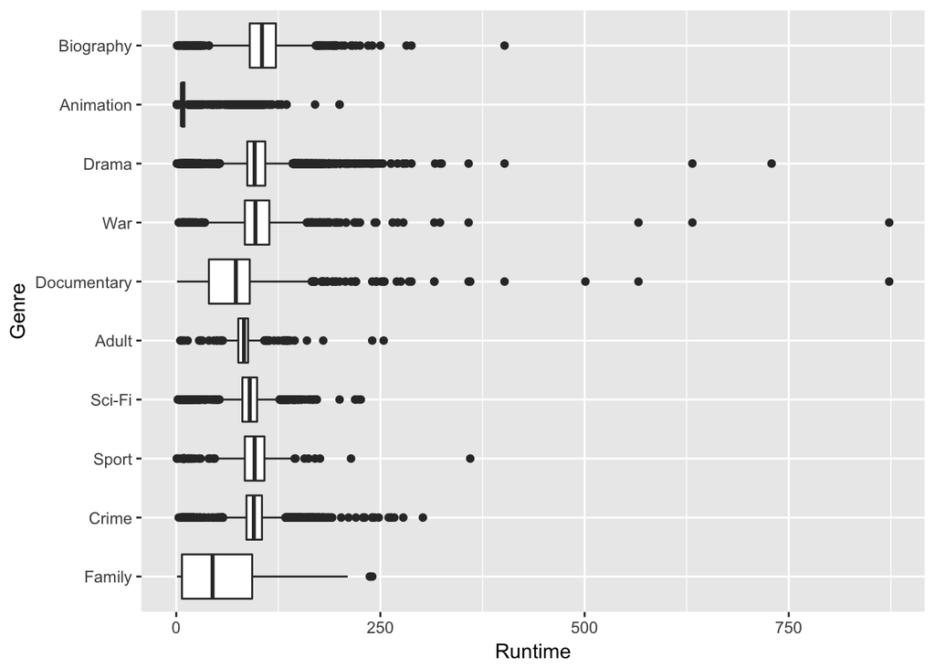

```r
# TODO: Plot Runtime distribution for top 10 most common genres
# ggplot(df3.long, aes(x=Runtime)) +
#   geom_density(aes(color=variable, group=variable)) +
#   ggtitle('Distribution of Runtimes by Movie Genre')

ggplot(df3.long, aes(as.factor(variable), Runtime)) +
  geom_boxplot() +
  coord_flip() +
  scale_x_discrete("Genre")
```

**Q**: Describe the interesting relationship(s) you observe. Are there any expected or unexpected trends that are evident?

**A**: One thing that immediately stood out to me was that in looking at the extreme outliers (Runtimes greater than 300 minutes for example or 5 hours), most of these very long movies tend to be Drama, War, and Documentaries, which fits anecdotally with my priors of what movies would be extremely long.

Animation films tend to be the shortest, which is expected as there are probably many short animation films. I was actually surprised to see that most animation films are very very short.

One that that was unexpected to me was that with the exception of Animation and Family films, most of the median runtimes for all the rest of the genres are very similar.

## 4. Eliminate mismatched rows

The dataframe was put together by merging two different sources of data and it is possible that the merging process was inaccurate in some cases (the merge was done based on movie title, but there are cases of different movies with the same title). There are 3 columns that contain date information: `Year` (numeric year), `Date` (numeric year), and `Released` (string representation of the release date).

Find and remove all rows where you suspect a merge error occurred based on a mismatch between these variables. To make sure subsequent analysis and modeling work well, avoid removing more than 10% of the rows that have a `Gross` value present.

*Note: Do not remove the rows with `Gross == NA` at this point, just use this a guideline.*

```r
# TODO: Remove rows with Year/Date/Released mismatch
library(lubridate)  # Used to extract year from Released
cols4 = c('Year', 'Date', 'Released', 'Gross')
df4 = df[cols4]
df4$released_year = year(df4$Released)
df4$not_matched = (df4$Year != df4$released_year) & (df4$Year != df4$Date) & (df4$Date != df4$released_year)

# Number of rows with non-null Gross Value
print(nrow(df[which(!is.na(df$Gross)), ]))
```

```
[1] 4558
```

```r
# Printing rows in the original data set
print(nrow(df))
```

```
[1] 40000
```

```r
df = df[which(df4$not_matched == FALSE | is.na(df4$not_matched)), ]
print(nrow(df))
```

```
[1] 39952
```

**Q**: What is your precise removal logic, and how many rows remain in the resulting dataset?

## 5. Explore `Gross` revenue

For the commercial success of a movie, production houses want to maximize Gross revenue. Investigate if Gross revenue is related to Budget, Runtime or Genre in any way.

*Note: To get a meaningful relationship, you may have to partition the movies into subsets such as short vs. long duration, or by genre, etc.*

```r
# TODO: Investigate if Gross Revenue is related to Budget, Runtime or Genre
cols = c('Title', 'Gross', 'Runtime', 'Budget', 'Released', 'Action', 'Adult', 'Adventure', 'Animation', 'Biography', 'Comedy', 'Crime', 'Documentary', 'Drama', 'Family', 'Fantasy', 'Film-Noir', 'Game-Show', 'History', 'Horror', 'Music', 'Musical', 'Mystery', 'N/A', 'News', 'Reality-TV', 'Romance', 'Sci-Fi', 'Short', 'Sport', 'Talk-Show', 'Thriller', 'War', 'Western')
df5 = df[cols]

print(summary(df5))
```

```
    Title               Gross              Runtime
 Length:39952       Min.   :0.000e+00   Min.   :  1.00
 Class :character   1st Qu.:5.000e+06   1st Qu.: 72.00
 Mode  :character   Median :3.006e+07   Median : 90.00
                    Mean   :9.057e+07   Mean   : 81.78
                    3rd Qu.:1.008e+08   3rd Qu.:101.00
                    Max.   :2.784e+09   Max.   :873.00
                    NA's   :35442       NA's   :751
     Budget             Released              Action
 Min.   :     1100   Min.   :1893-05-09   Min.   :0.0000
 1st Qu.:  5000000   1st Qu.:1959-02-04   1st Qu.:0.0000
 Median : 18000000   Median :1989-10-06   Median :0.0000
 Mean   : 31952913   Mean   :1980-12-02   Mean   :0.1104
 3rd Qu.: 40000000   3rd Qu.:2001-11-07   3rd Qu.:0.0000
 Max.   :425000000   Max.   :2018-08-01   Max.   :1.0000
 NA's   :35442       NA's   :4949
     Adult           Adventure         Animation         Biography
 Min.   :0.00000   Min.   :0.00000   Min.   :0.00000   Min.   :0.00000
 1st Qu.:0.00000   1st Qu.:0.00000   1st Qu.:0.00000   1st Qu.:0.00000
 Median :0.00000   Median :0.00000   Median :0.00000   Median :0.00000
 Mean   :0.01056   Mean   :0.07324   Mean   :0.06976   Mean   :0.02768
 3rd Qu.:0.00000   3rd Qu.:0.00000   3rd Qu.:0.00000   3rd Qu.:0.00000
 Max.   :1.00000   Max.   :1.00000   Max.   :1.00000   Max.   :1.00000

     Comedy           Crime         Documentary          Drama
 Min.   :0.0000   Min.   :0.0000   Min.   :0.00000   Min.   :0.0000
 1st Qu.:0.0000   1st Qu.:0.0000   1st Qu.:0.00000   1st Qu.:0.0000
 Median :0.0000   Median :0.0000   Median :0.00000   Median :0.0000
 Mean   :0.3212   Mean   :0.1014   Mean   :0.07624   Mean   :0.3963
 3rd Qu.:1.0000   3rd Qu.:0.0000   3rd Qu.:0.00000   3rd Qu.:1.0000
 Max.   :1.0000   Max.   :1.0000   Max.   :1.00000   Max.   :1.0000

     Family           Fantasy          Film-Noir          Game-Show
 Min.   :0.00000   Min.   :0.00000   Min.   :0.000000   Min.   :0.00e+00
 1st Qu.:0.00000   1st Qu.:0.00000   1st Qu.:0.000000   1st Qu.:0.00e+00
 Median :0.00000   Median :0.00000   Median :0.000000   Median :0.00e+00
 Mean   :0.06638   Mean   :0.03502   Mean   :0.008811   Mean   :5.01e-05
 3rd Qu.:0.00000   3rd Qu.:0.00000   3rd Qu.:0.000000   3rd Qu.:0.00e+00
 Max.   :1.00000   Max.   :1.00000   Max.   :1.000000   Max.   :1.00e+00

```

[output cut: 24 more lines]

```
     Sport           Talk-Show            Thriller            War
 Min.   :0.00000   Min.   :0.0000000   Min.   :0.00000   Min.   :0.00000
 1st Qu.:0.00000   1st Qu.:0.0000000   1st Qu.:0.00000   1st Qu.:0.00000
 Median :0.00000   Median :0.0000000   Median :0.00000   Median :0.00000
 Mean   :0.01314   Mean   :0.0001001   Mean   :0.08438   Mean   :0.02676
 3rd Qu.:0.00000   3rd Qu.:0.0000000   3rd Qu.:0.00000   3rd Qu.:0.00000
 Max.   :1.00000   Max.   :1.0000000   Max.   :1.00000   Max.   :1.00000

    Western
 Min.   :0.00000
 1st Qu.:0.00000
 Median :0.00000
 Mean   :0.03289
 3rd Qu.:0.00000
 Max.   :1.00000
```

```r
print(head(df5))
```

```
              Title Gross Runtime Budget   Released Action Adult Adventure
1 39 Pounds of Love    NA      70     NA 2005-04-08      0     0         0
2              3:am    NA      21     NA 2005-01-25      0     0         0
3   500 Years Later    NA     106     NA 2005-02-24      0     0         0
4         5th World    NA      75     NA 2005-01-20      0     0         0
5                90    NA      14     NA 2005-03-12      0     0         0
6  Abel Raises Cain    NA      82     NA 2005-01-23      0     0         0
  Animation Biography Comedy Crime Documentary Drama Family Fantasy
1         0         1      0     0           1     0      0       0
2         0         0      0     0           0     0      0       0
3         0         0      0     0           1     0      0       0
4         0         0      0     0           0     1      0       0
5         0         0      0     0           0     0      0       0
6         0         1      0     0           1     0      0       0
  Film-Noir Game-Show History Horror Music Musical Mystery N/A News
1         0         0       0      0     0       0       0   0    0
2         0         0       0      0     0       0       0   0    0
3         0         0       0      0     0       0       0   0    0
4         0         0       0      0     0       0       0   0    0
5         0         0       0      0     0       0       0   0    0
6         0         0       0      0     0       0       0   0    0
  Reality-TV Romance Sci-Fi Short Sport Talk-Show Thriller War Western
1          0       1      0     0     0         0        0   0       0
2          0       0      0     1     0         0        1   0       0
3          0       0      0     0     0         0        0   0       0
4          0       1      0     0     0         0        0   0       0
5          0       0      0     1     0         0        0   1       0
6          0       0      0     0     0         0        0   0       0
```

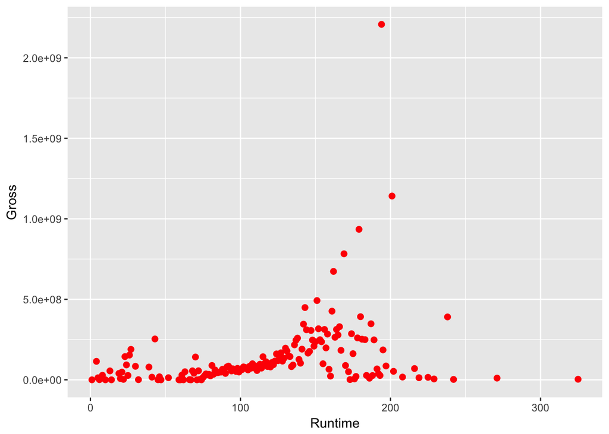

```r
ggplot(df, aes(Runtime, Gross)) +
  stat_summary(fun.y = "mean", colour = "red", size = 2, geom = "point")
```

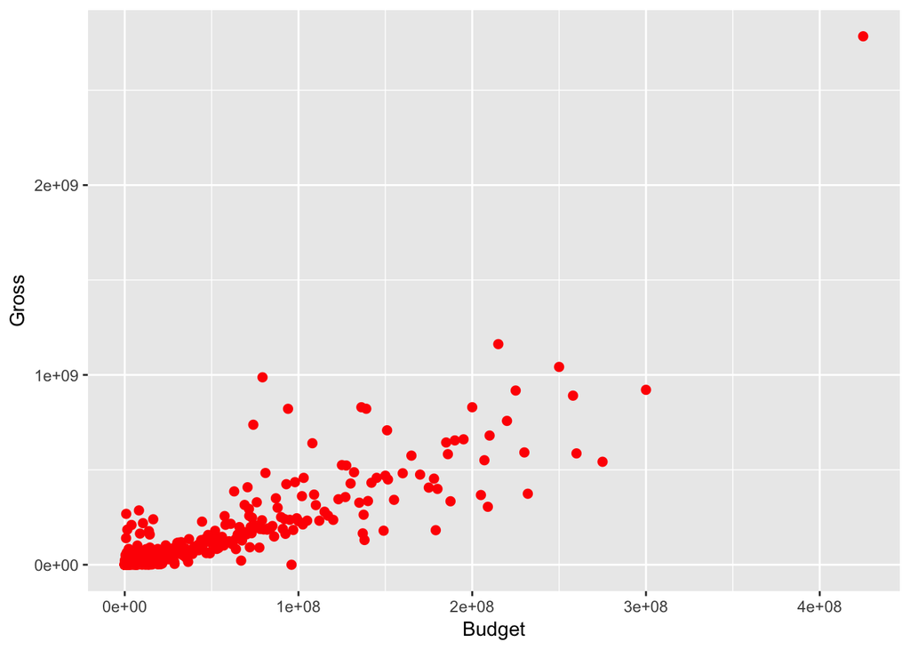

```r
ggplot(df, aes(Budget, Gross)) +
  stat_summary(fun.y = "mean", colour = "red", size = 2, geom = "point")
```

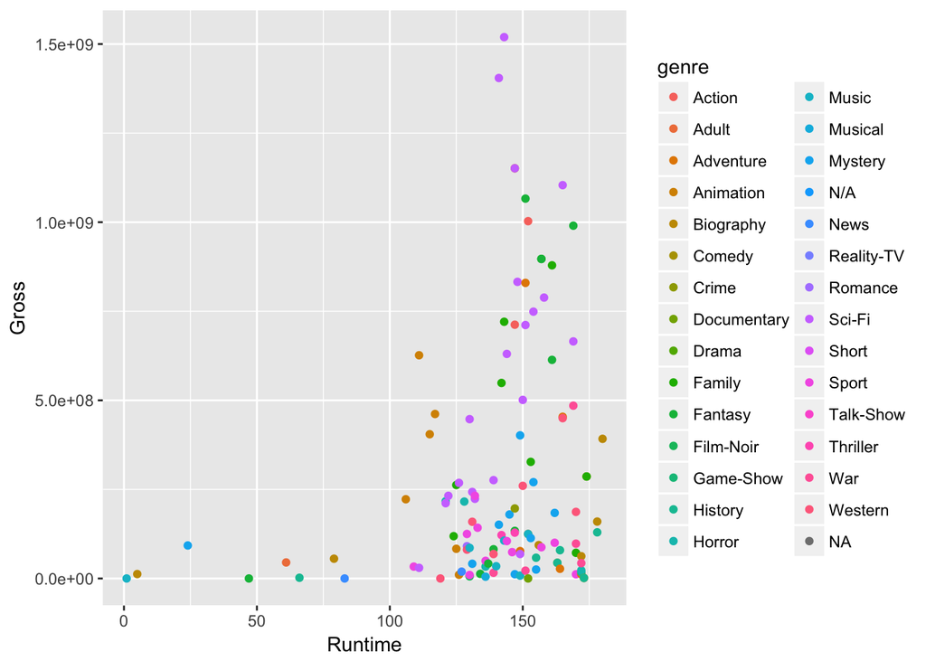

```r
# Next melt the df to get genre as one column (like in question 3) and plot grouped by genre
df5.long = melt(df5, id.vars=c('Title', 'Gross', 'Runtime', 'Budget', 'Released'), variable.name='genre')

# Removing rows where value is 0 to answer the question
# This is because when value is 0, that means movie is not that genre.
df5.long = df5.long[apply(df5.long['value'], 1, function(z) !any(z==0)),]

library(plyr)
df5.long.runtime <- ddply(df5.long, c('Runtime', 'genre'), function(x) mean(x$Gross))
names(df5.long.runtime)[names(df5.long.runtime) == 'V1'] <- 'Gross'
df5.long.runtime = df5.long.runtime[!df5.long.runtime$Runtime > 180,]  # Removing movies greater than 3 hours

df5.long.budget <- ddply(df5.long, c('Budget', 'genre'), function(x) mean(x$Gross))
names(df5.long.budget)[names(df5.long.budget) == 'V1'] <- 'Gross'

ggplot(df5.long.runtime, aes(Runtime, Gross)) +
  geom_point(aes(color=genre, group=genre))
```

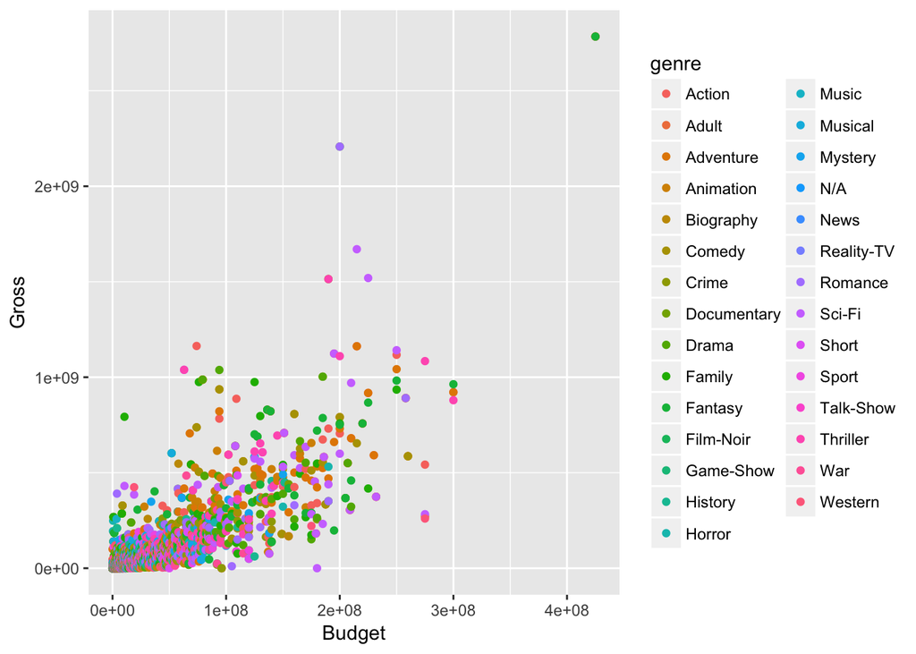

```r
ggplot(df5.long.budget, aes(Budget, Gross)) +
  geom_point(aes(color=genre, group=genre))
```

**Q**: Did you find any observable relationships or combinations of Budget/Runtime/Genre that result in high Gross revenue? If you divided the movies into different subsets, you may get different answers for them - point out interesting ones.

**A**:

Yes, it seems that in the aggregate, Gross revenue is positive correlated with Runtime, but only to a certain extent. After about 3 hours or so, the relationship is much murkier. Gross Revenue seems generally positively correlated with Budget.

```r
# TODO: Investigate if Gross Revenue is related to Release Month
print(summary(df5.long))
```

```
    Title               Gross              Runtime
 Length:79959       Min.   :0.000e+00   Min.   :  1.00
 Class :character   1st Qu.:6.882e+06   1st Qu.: 69.00
 Mode  :character   Median :3.457e+07   Median : 90.00
                    Mean   :9.891e+07   Mean   : 81.15
                    3rd Qu.:1.106e+08   3rd Qu.:102.00
                    Max.   :2.784e+09   Max.   :873.00
                    NA's   :68815       NA's   :1099
     Budget             Released              genre           value
 Min.   :     1100   Min.   :1893-05-09   Drama  :15832   Min.   :1
 1st Qu.:  7000000   1st Qu.:1956-08-16   Comedy :12833   1st Qu.:1
 Median : 20000000   Median :1989-04-28   Short  : 6516   Median :1
 Mean   : 35134828   Mean   :1980-04-16   Romance: 4966   Mean   :1
 3rd Qu.: 48000000   3rd Qu.:2001-12-13   Action : 4409   3rd Qu.:1
 Max.   :425000000   Max.   :2018-08-01   Crime  : 4053   Max.   :1
 NA's   :68815       NA's   :8537         (Other):31350
```

```r
print(head(df5.long))
```

```
                    Title Gross Runtime Budget   Released  genre value
23 Assault on Precinct 13    NA     109     NA 2005-01-19 Action     1
39            Boy s tenyu    NA     132     NA 2005-03-17 Action     1
41           Broadcast 23    NA       7     NA       <NA> Action     1
47               Chok-Dee    NA     105     NA 2005-02-16 Action     1
48                 Choker    NA      93     NA 2006-10-10 Action     1
69          Dust to Glory    NA      97     NA 2005-04-22 Action     1
```

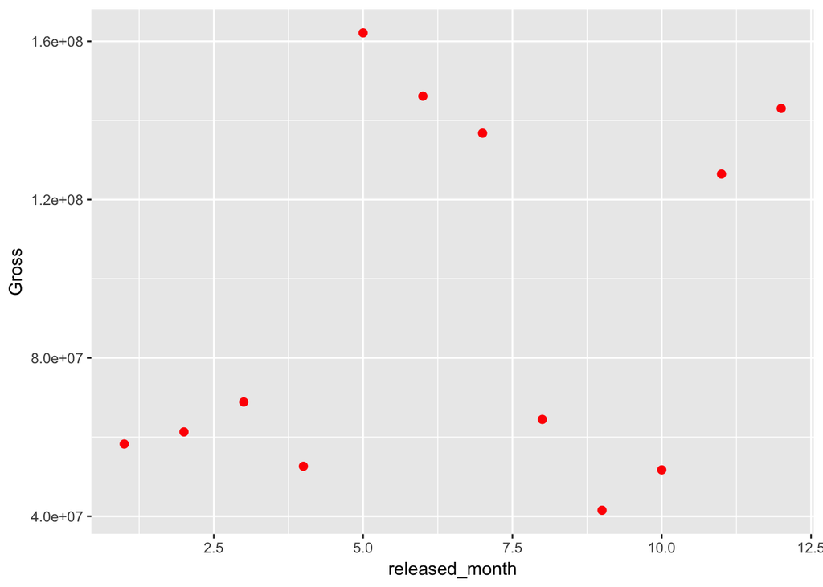

```r
df$released_month = month(df$Released)
ggplot(df, aes(released_month, Gross)) +
  stat_summary(fun.y = "mean", colour = "red", size = 2, geom = "point")
```

There is definitely a relationship of Gross Revenue and release month. Summer month movies and holiday movies gross significantly more revenue than movies released in other months.

## 6. Process `Awards` column

The variable `Awards` describes nominations and awards in text format. Convert it to 2 numeric columns, the first capturing the number of wins, and the second capturing nominations. Replace the `Awards` column with these new columns, and then study the relationship of `Gross` revenue with respect to them.

*Note: The format of the `Awards` column is not standard; you may have to use regular expressions to find the relevant values. Try your best to process them, and you may leave the ones that don’t have enough information as NAs or set them to 0s.*

```r
# TODO: Convert Awards to 2 numeric columns: wins and nominations
library(stringi)
cols = c('Title', 'Awards', 'Gross')
df6 = df[cols]
print(unique(df6$Awards))
```

```
   [1] "3 wins."
   [2] "N/A"
   [3] "2 wins."
   [4] "1 win."
   [5] "5 wins."
   [6] "5 wins & 4 nominations."
   [7] "1 win & 1 nomination."
   [8] "2 wins & 1 nomination."
   [9] "1 nomination."
  [10] "1 win & 8 nominations."
  [11] "1 win & 2 nominations."
  [12] "1 win & 13 nominations."
  [13] "15 nominations."
  [14] "2 nominations."
  [15] "28 wins & 3 nominations."
```

[output cut: 2027 more lines]

```r
print(summary(df6))
```

```
    Title              Awards              Gross
 Length:39952       Length:39952       Min.   :0.000e+00
 Class :character   Class :character   1st Qu.:5.000e+06
 Mode  :character   Mode  :character   Median :3.006e+07
                                       Mean   :9.057e+07
                                       3rd Qu.:1.008e+08
                                       Max.   :2.784e+09
                                       NA's   :35442
```

```r
print(head(df6))
```

```
              Title  Awards Gross
1 39 Pounds of Love 3 wins.    NA
2              3:am     N/A    NA
3   500 Years Later 2 wins.    NA
4         5th World  1 win.    NA
5                90     N/A    NA
6  Abel Raises Cain 5 wins.    NA
```

```r
awards = stri_extract_all(df6$Awards, regex="\\d+")
award_labels = stri_extract_all(df6$Awards, regex="win|won|nomin")
print(head(awards))
```

```
[[1]]
[1] "3"

[[2]]
[1] NA

[[3]]
[1] "2"

[[4]]
[1] "1"

[[5]]
[1] NA

[[6]]
[1] "5"
```

```r
print(head(award_labels))
```

```
[[1]]
[1] "win"

[[2]]
[1] NA

[[3]]
[1] "win"

[[4]]
[1] "win"

[[5]]
[1] NA

[[6]]
[1] "win"
```

```r
wins_list = c()
nominations_list = c()

for (i in 1:length(awards)){
    wins = 0
    nominations = 0
    for(j in 1:length(awards[[i]])){
        if(!is.na(award_labels[[i]][j]) & (award_labels[[i]][j] == 'wins' | award_labels[[i]][j] == 'win' | award_labels[[i]][j] == 'won')){
            wins = wins + as.numeric(awards[[i]][j])
        } else if (!is.na(award_labels[[i]][j]) & award_labels[[i]][j] == 'nomin'){
            nominations = nominations + as.numeric(awards[[i]][j])
        }
    }
    wins_list = c(wins_list, wins)
    nominations_list = c(nominations_list, nominations)
}

df$wins = wins_list
df$nominations = nominations_list

print(head(df[c('Awards', 'wins', 'nominations')], 20))
```

```
                    Awards wins nominations
1                  3 wins.    3           0
2                      N/A    0           0
3                  2 wins.    2           0
4                   1 win.    1           0
5                      N/A    0           0
6                  5 wins.    5           0
7                      N/A    0           0
8                      N/A    0           0
9                      N/A    0           0
10                     N/A    0           0
11                     N/A    0           0
12                     N/A    0           0
13 5 wins & 4 nominations.    5           4
14                     N/A    0           0
15   1 win & 1 nomination.    1           1
16                  1 win.    1           0
17                     N/A    0           0
18  2 wins & 1 nomination.    2           1
19                     N/A    0           0
20           1 nomination.    0           1
```

**Q**: How did you construct your conversion mechanism? How many rows had valid/non-zero wins or nominations?

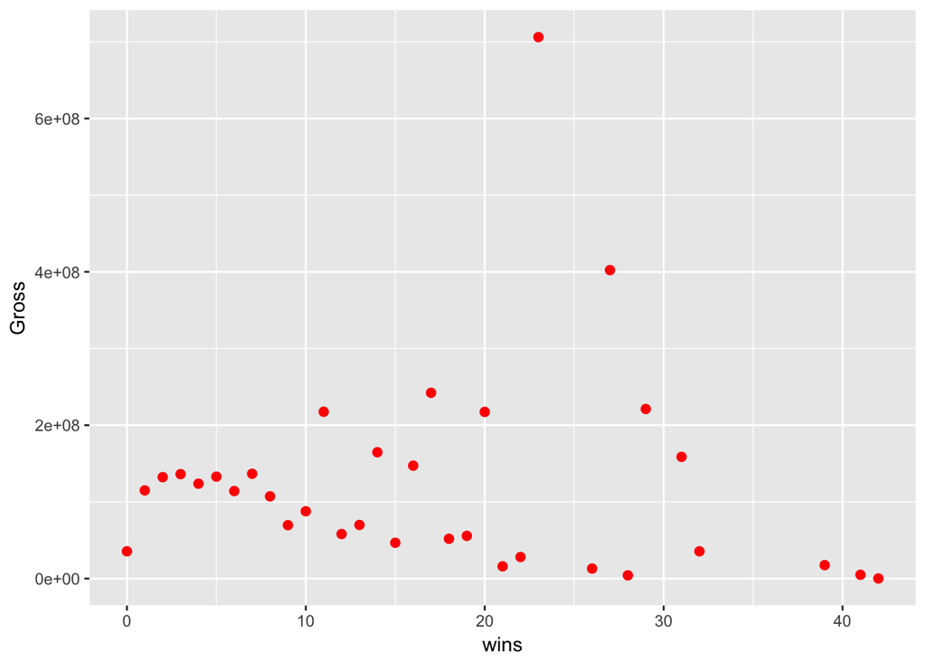

```r
# TODO: Plot Gross revenue against wins and nominations
ggplot(df, aes(wins, Gross)) +
  stat_summary(fun.y = "mean", colour = "red", size = 2, geom = "point")
```

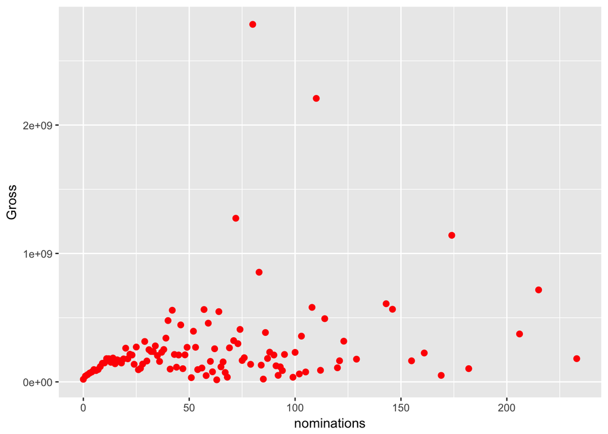

```r
ggplot(df, aes(nominations, Gross)) +
  stat_summary(fun.y = "mean", colour = "red", size = 2, geom = "point")
```

**Q**: How does the gross revenue vary by number of awards won and nominations received?

**A**: Surprisingly, there does not seem to be much of a relationship between gross revenue and awards won.

## 7. Movie ratings from IMDb and Rotten Tomatoes

There are several variables that describe ratings, including IMDb ratings (`imdbRating` represents average user ratings and `imdbVotes` represents the number of user ratings), and multiple Rotten Tomatoes ratings (represented by several variables pre-fixed by `tomato`). Read up on such ratings on the web (for example rottentomatoes.com/about and www.imdb.com/help/show_leaf?votestopfaq).

Investigate the pairwise relationships between these different descriptors using graphs.

```r
library(GGally)

# TODO: Illustrate how ratings from IMDb and Rotten Tomatoes are related
cols = c('imdbRating', 'imdbVotes', 'tomatoMeter', 'tomatoImage', 'tomatoRating', 'tomatoReviews',
         'tomatoFresh', 'tomatoRotten', 'tomatoConsensus', 'tomatoUserMeter', 'tomatoUserRating',
         'tomatoUserReviews')
df7 = df[cols]

print(summary(df7))
```

```
   imdbRating      imdbVotes        tomatoMeter     tomatoImage
 Min.   :1.000   Min.   :      5   Min.   :  0.00   Length:39952
 1st Qu.:5.600   1st Qu.:     60   1st Qu.: 35.00   Class :character
 Median :6.400   Median :    211   Median : 63.00   Mode  :character
 Mean   :6.234   Mean   :  12025   Mean   : 58.56
 3rd Qu.:7.100   3rd Qu.:   1294   3rd Qu.: 83.00
 Max.   :9.800   Max.   :1684836   Max.   :100.00
 NA's   :1134    NA's   :1172      NA's   :30539
  tomatoRating   tomatoReviews     tomatoFresh      tomatoRotten
 Min.   :0.000   Min.   :  1.00   Min.   :  0.00   Min.   :  0.00
 1st Qu.:4.800   1st Qu.: 11.00   1st Qu.:  5.00   1st Qu.:  3.00
 Median :6.000   Median : 28.00   Median : 15.00   Median :  9.00
 Mean   :5.875   Mean   : 57.47   Mean   : 34.32   Mean   : 23.14
 3rd Qu.:7.000   3rd Qu.: 88.00   3rd Qu.: 43.00   3rd Qu.: 30.00
 Max.   :9.800   Max.   :360.00   Max.   :343.00   Max.   :249.00
 NA's   :30548   NA's   :30494    NA's   :30494    NA's   :30494
 tomatoConsensus    tomatoUserMeter  tomatoUserRating tomatoUserReviews
 Length:39952       Min.   :  0.00   Min.   :0.000    Min.   :       0
 Class :character   1st Qu.: 38.00   1st Qu.:2.900    1st Qu.:      46
 Mode  :character   Median : 57.00   Median :3.300    Median :     341
                    Mean   : 55.51   Mean   :3.264    Mean   :   93049
                    3rd Qu.: 75.00   3rd Qu.:3.600    3rd Qu.:    4947
                    Max.   :100.00   Max.   :5.000    Max.   :35794556
                    NA's   :21936    NA's   :21852    NA's   :15980
```

```r
print(head(df7))
```

```
  imdbRating imdbVotes tomatoMeter tomatoImage tomatoRating tomatoReviews
1        6.8       234          NA         N/A           NA            NA
2        8.2        13          NA         N/A           NA            NA
3        7.0       161          NA         N/A           NA            NA
4        6.4        31          NA         N/A           NA            NA
5        8.3        18          NA         N/A           NA            NA
6        7.5       197          NA         N/A           NA            NA
  tomatoFresh tomatoRotten tomatoConsensus tomatoUserMeter
1          NA           NA             N/A              NA
2          NA           NA             N/A              NA
3          NA           NA             N/A              88
4          NA           NA             N/A              NA
5          NA           NA             N/A              NA
6          NA           NA             N/A              60
  tomatoUserRating tomatoUserReviews
1               NA                50
2               NA                NA
3              4.2               341
4               NA                 8
5               NA                NA
6              4.0                67
```

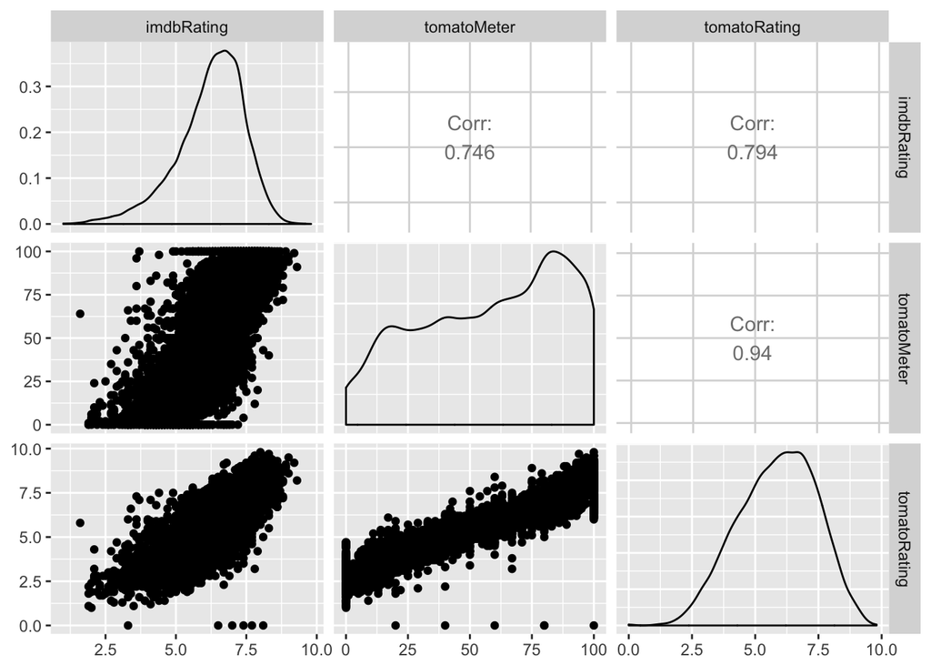

```r
ggpairs(df7, columns=c('imdbRating', 'tomatoMeter', 'tomatoRating'), aes())
```

**Q**: Comment on the similarities and differences between the user ratings of IMDb and the critics ratings of Rotten Tomatoes.

**A**: First off, it’s interesting to note that we have significantly more data of IMDB ratings than Rotten tomatoes. In our data, we have about 1100 movies with missing IMDB ratings. However, we have close to 30,000 movies with missing Rotten Tomatoes ratings.

In the plot above we plot the `ggpairs` of `imdbRating`, `tomatoMeter`, and `tomatoRating`. Notice that the correlation between `tomatoMeter` and `tomatoRating` is very high, at 0.94. This makes sense as it’s from the same source. The correlation between `tomatoMeter` and `imdbRating` is a bit lower, at around 0.746 vs 0.794 which is the correlation between `tomatoRating` and `imdbRating`.

Looking at the summary of the variables as well, it looks like `imdbRating` and `tomatoRating` are rated on similar scales. `imdbRating` looks like it’s rated on a scale of 1 to 10, while `tomatoRating` looks like it’s rated on a scale of 0 to 9.8. However, `tomatoMeter` looks like it’s scaled from 0 to 100.

## 8. Ratings and awards

These ratings typically reflect the general appeal of the movie to the public or gather opinions from a larger body of critics. Whereas awards are given by professional societies that may evaluate a movie on specific attributes, such as artistic performance, screenplay, sound design, etc.

Study the relationship between ratings and awards using graphs (awards here refers to wins and/or nominations).

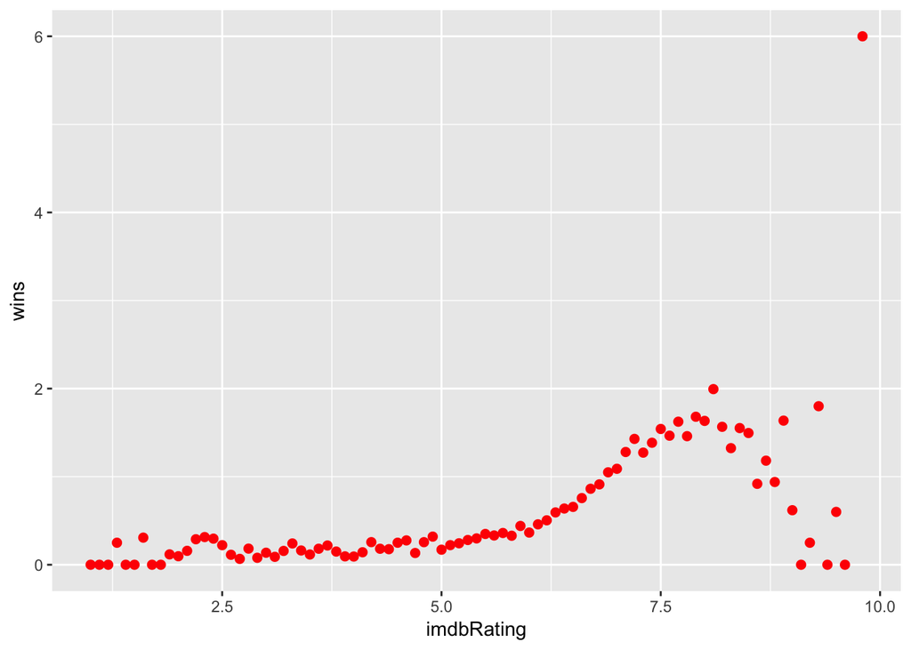

```r
# TODO: Show how ratings and awards are related
ggplot(df, aes(imdbRating, wins)) +
  stat_summary(fun.y = "mean", colour = "red", size = 2, geom = "point")
```

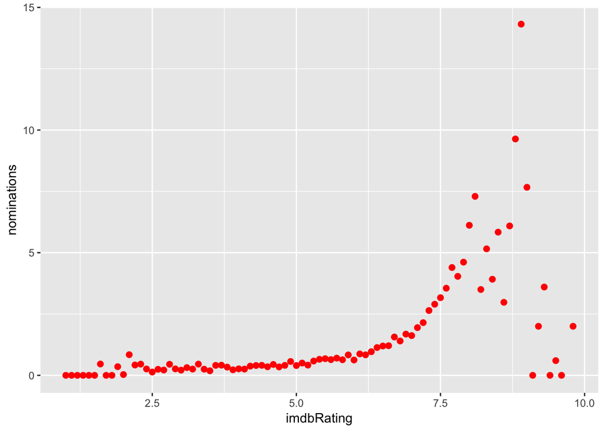

```r
ggplot(df, aes(imdbRating, nominations)) +
  stat_summary(fun.y = "mean", colour = "red", size = 2, geom = "point")
```

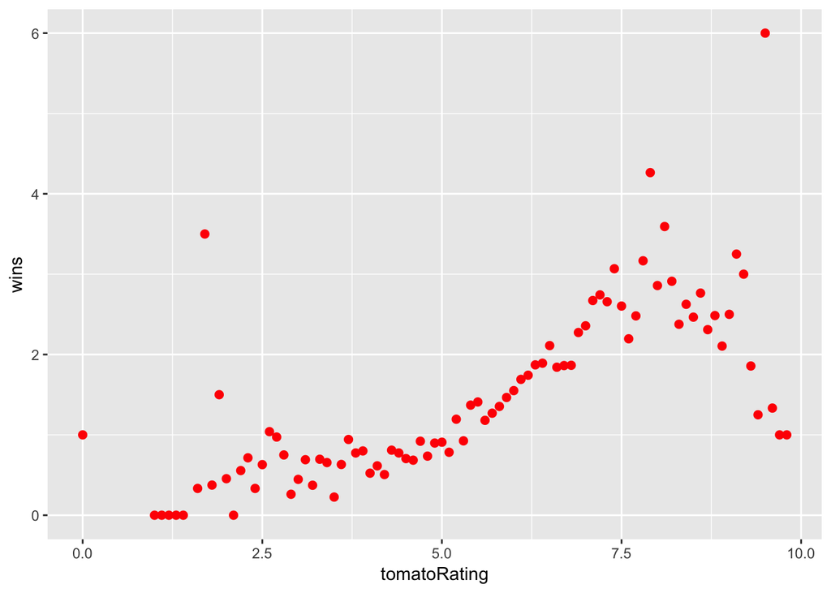

```r
ggplot(df, aes(tomatoRating, wins)) +
  stat_summary(fun.y = "mean", colour = "red", size = 2, geom = "point")
```

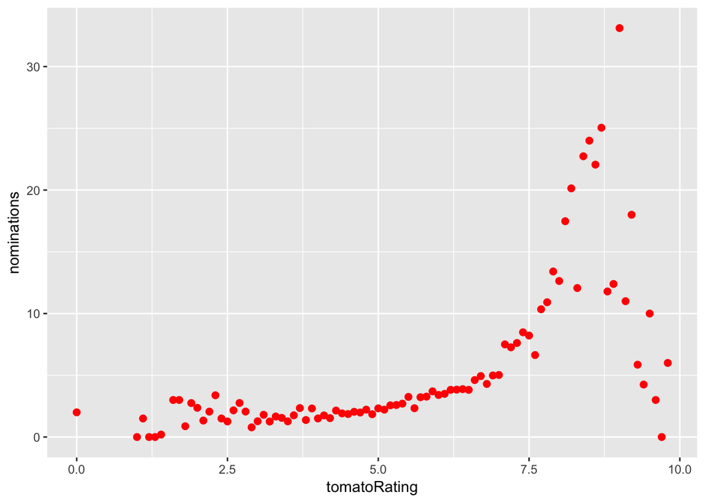

```r
ggplot(df, aes(tomatoRating, nominations)) +
  stat_summary(fun.y = "mean", colour = "red", size = 2, geom = "point")
```

```r
mod1 = lm(wins ~ imdbRating, data = df)
summary(mod1)
```

```
Call:
lm(formula = wins ~ imdbRating, data = df)

Residuals:
   Min     1Q Median     3Q    Max
-1.938 -0.883 -0.531  0.067 52.695

Coefficients:
             Estimate Std. Error t value Pr(>|t|)
(Intercept) -1.439096   0.054933  -26.20   <2e-16 ***
imdbRating   0.351807   0.008653   40.66   <2e-16 ***
---
Signif. codes:  0 '***' 0.001 '**' 0.01 '*' 0.05 '.' 0.1 ' ' 1

Residual standard error: 2.047 on 38816 degrees of freedom
  (1134 observations deleted due to missingness)
Multiple R-squared:  0.04084,   Adjusted R-squared:  0.04082
F-statistic:  1653 on 1 and 38816 DF,  p-value: < 2.2e-16
```

```r
mod1 = lm(nominations ~ imdbRating, data = df)
summary(mod1)
```

```
Call:
lm(formula = nominations ~ imdbRating, data = df)

Residuals:
    Min      1Q  Median      3Q     Max
 -4.496  -1.947  -1.156   0.019 229.822

Coefficients:
            Estimate Std. Error t value Pr(>|t|)
(Intercept) -3.94098    0.16743  -23.54   <2e-16 ***
imdbRating   0.87885    0.02637   33.32   <2e-16 ***
---
Signif. codes:  0 '***' 0.001 '**' 0.01 '*' 0.05 '.' 0.1 ' ' 1

Residual standard error: 6.238 on 38816 degrees of freedom
  (1134 observations deleted due to missingness)
Multiple R-squared:  0.02781,   Adjusted R-squared:  0.02778
F-statistic:  1110 on 1 and 38816 DF,  p-value: < 2.2e-16
```

```r
mod1 = lm(wins ~ tomatoRating, data = df)
summary(mod1)
```

```
Call:
lm(formula = wins ~ tomatoRating, data = df)

Residuals:
   Min     1Q Median     3Q    Max
-3.348 -1.445 -0.744  0.305 51.353

Coefficients:
             Estimate Std. Error t value Pr(>|t|)
(Intercept)  -1.30926    0.12455  -10.51   <2e-16 ***
tomatoRating  0.50076    0.02052   24.41   <2e-16 ***
---
Signif. codes:  0 '***' 0.001 '**' 0.01 '*' 0.05 '.' 0.1 ' ' 1

Residual standard error: 3.043 on 9402 degrees of freedom
  (30548 observations deleted due to missingness)
Multiple R-squared:  0.05958,   Adjusted R-squared:  0.05948
F-statistic: 595.7 on 1 and 9402 DF,  p-value: < 2.2e-16
```

```r
mod1 = lm(nominations ~ tomatoRating, data = df)
summary(mod1)
```

```
Call:
lm(formula = nominations ~ tomatoRating, data = df)

Residuals:
    Min      1Q  Median      3Q     Max
-14.050  -4.886  -1.832   1.584 220.595

Coefficients:
             Estimate Std. Error t value Pr(>|t|)
(Intercept)  -8.74148    0.46064  -18.98   <2e-16 ***
tomatoRating  2.34962    0.07588   30.96   <2e-16 ***
---
Signif. codes:  0 '***' 0.001 '**' 0.01 '*' 0.05 '.' 0.1 ' ' 1

Residual standard error: 11.25 on 9402 degrees of freedom
  (30548 observations deleted due to missingness)
Multiple R-squared:  0.09253,   Adjusted R-squared:  0.09244
F-statistic: 958.7 on 1 and 9402 DF,  p-value: < 2.2e-16
```

**Q**: How good are these ratings in terms of predicting the success of a movie in winning awards or nominations? Is there a high correlation between two variables?

**A**: One extremely interesting trend from the graph above is that for both `imdbRatings` and `tomatoRatings` generally there is a positive correlation between ratings and both wins and nominations. But very interestingly enough, the relationship is actually not monotonic. In the extremely upper regions of ratings, the number of wins and nominations actually decrease!

I fit a linear regression between wins and nominations against ratings field. Notice that in each regression the coefficient is significant, which means that there is a significant positive relationship between rating and nominations and wins. However, the R^2 is relatively low, so the correlation is relatively low.